# Store 12631

## Statistical Analysis for store 12631

To begin with, splitting the dataset into training set and testing set is a must. By selecting the 8.5:1.5 ratio of splitting the original dataset, we can fit the model and test to see the accuracy for further prediction.

```r
train_12631 <- window(ts_12631, end = c(05,75), frequency = 7)
test_12631 <- window(ts_12631, start = c(05,76))
```

### Holt-Winters Method

```r
## Initial Holt-Winters with exponential smoothing
HW_12631 <- HoltWinters(ts_12631, beta = FALSE)
HW_12631
```

```
Holt-Winters exponential smoothing without trend and with additive seasonal component.

Call:
HoltWinters(x = ts_12631, beta = FALSE)

Smoothing parameters:
 alpha: 0.08478591
 beta : FALSE
 gamma: 0.1869343

Coefficients:
         [,1]
a  261.866331
s1   5.904235
s2  10.379453
s3  61.167156
s4  40.234635
s5 -26.552098
s6  -0.704215
s7 -18.869742
```

```r
## Initial ETS model with automatic fitting
ETS_12631 <- ets(ts_12631, model = 'ZZZ')
ETS_12631
```

```
ETS(M,Ad,M)

Call:
 ets(y = ts_12631, model = "ZZZ")

  Smoothing parameters:
    alpha = 1e-04
    beta  = 1e-04
    gamma = 0.002
    phi   = 0.9745

  Initial states:
    l = 213.5467
    b = 1.9142
    s = 1.028 0.9728 0.9128 0.9858 0.8681 1.1111
           1.1214

  sigma:  0.1408

     AIC     AICc      BIC
1232.106 1236.196 1266.357
```

We are going to apply the model onto the training and testing set to do the forecasting.

#### Forecasting on Training Set

```r
#Holt-Winters
train_HW_12631 <- HoltWinters(train_12631, beta = FALSE)
forecast_HW_12631  <- forecast(train_HW_12631, h = 14)
#ets
train_ets_12631 <- ets(train_12631, model = 'ZZZ')
forecast_ets_12631  <- forecast(train_ets_12631, h = 14)

plot(train_HW_12631, main="Holt-Winters vs. ETS(MAM) on training set",
     xlab="Time",
     ylab="Lettuce Demand", lty = 1, col = "black", frame.plot = FALSE)
lines(fitted(train_ets_12631), col = "Blue", lty = 2)
```

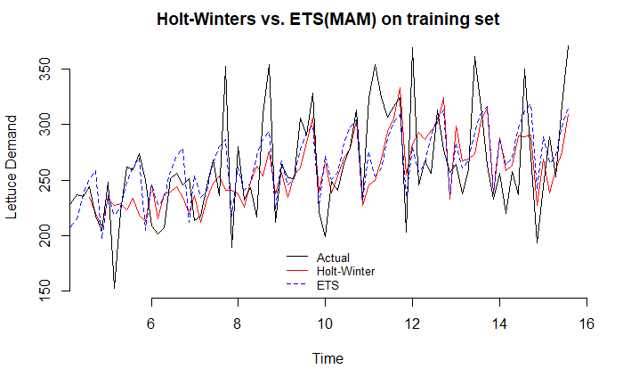

```r
legend("bottom", legend=c("Actual","Holt-Winter", "ETS"), col=c("black", "red", "blue"), box.lty=0, lty=c(1,1,2), cex=0.8)
```

*Figure 2.1:* *This figure provides the fitted lines for holt-winter and ETS on store 12631.*

```r
## Accuracy Comparison
acc_ets_HW_12631 <- rbind(forecast::accuracy(forecast_HW_12631,
                                       test_12631),
                        forecast::accuracy(forecast_ets_12631,
                                 test_12631))

acc_ets_HW_12631_df <- data.frame(acc_ets_HW_12631,
                                row.names = c('HW_on_Train', 'HW_on_Test',
                                              'ETS_on_Train', 'ETS_on_Test'))

acc_ets_HW_12631_df %>%  kable(caption = "Accuracy: Holt-Winter vs. ETS",
                                  align = 'c') %>%
  kable_styling() %>%
  pack_rows("Holt-Winters", 1, 2) %>%
  pack_rows("ETS(M,A,M)", 3, 4)
```

Accuracy: Holt-Winter vs. ETS

|  | ME | RMSE | MAE | MPE | MAPE | MASE | ACF1 | Theil.s.U |
| --- | --- | --- | --- | --- | --- | --- | --- | --- |
| **Holt-Winters** |  |  |  |  |  |  |  |  |
| HW_on_Train | 5.173914 | 39.87504 | 30.79227 | -0.0251659 | 11.607073 | 0.8658243 | -0.0161969 | NA |
| HW_on_Test | -12.432684 | 45.09437 | 41.33036 | -6.8631226 | 16.033452 | 1.1621370 | 0.0318890 | 0.7060648 |
| **ETS(M,A,M)** |  |  |  |  |  |  |  |  |
| ETS_on_Train | -2.160748 | 33.72579 | 25.67783 | -2.5016942 | 9.961289 | 0.7220155 | 0.0324235 | NA |
| ETS_on_Test | -21.361420 | 48.24049 | 41.88100 | -10.3673035 | 16.591165 | 1.1776202 | -0.1314206 | 0.7898032 |

*Table 2.1:* *This table provides the comparison information for store 12631.*

#### Final ETS Model

```r
final_ets_12631 <- forecast(ETS_12631, h = 14)
final_ets_12631_1 <- as.data.frame(forecast(ETS_12631, h = 14))
final_ets_12631_df <- data.frame(final_ets_12631_1$`Point Forecast`,
                     row.names = c('16/06/15', '17/06/15',
                                   '18/06/15', '19/06/15',
                                   '20/06/15', '21/06/15',
                                   '22/06/15','23/06/15',
                                   '24/06/15', '25/06/15',
                                   '26/06/15', '27/06/15',
                                   '28/06/15', '29/06/15'))
final_ets_12631_df %>%
  kable(caption = "14 Day ETS Forecast for Store 12631", align = 'c', col.names = 'Lettuce Demand') %>%
  kable_styling(full_width = F)
```

14 Day ETS Forecast for Store 12631

|  | Lettuce Demand |
| --- | --- |
| 16/06/15 | 274.2683 |
| 17/06/15 | 289.9449 |
| 18/06/15 | 316.5410 |
| 19/06/15 | 313.7897 |
| 20/06/15 | 245.1401 |
| 21/06/15 | 278.4584 |
| 22/06/15 | 257.8716 |
| 23/06/15 | 275.0112 |
| 24/06/15 | 290.7099 |
| 25/06/15 | 317.3545 |
| 26/06/15 | 314.5752 |
| 27/06/15 | 245.7378 |
| 28/06/15 | 279.1198 |
| 29/06/15 | 258.4683 |

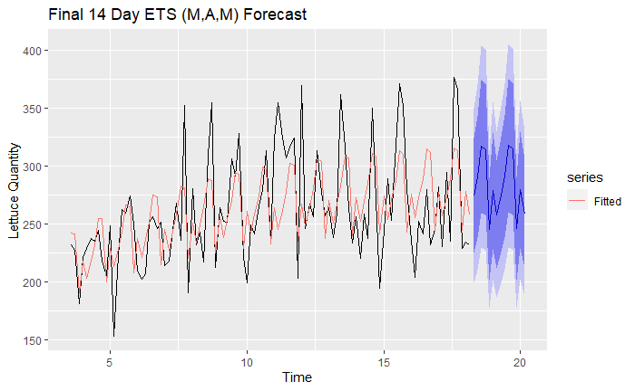

```r
autoplot(final_ets_12631,
         main = 'Final 14 Day ETS (M,A,M) Forecast',
         ylab = 'Lettuce Quantity',
         xlab = 'Time') +
  autolayer(fitted(final_ets_12631),
            series = 'Fitted', na.rm=TRUE)
```

*Table 2.2:* *This table provides the ETS forecasting fitted value for store 12631.*  
*Figure 2.2:* *This figure provides the forecasting plot for store 12631.*

### ARIMA Forecast Models

I then develop the ARIMA model for store 12631 to forecast the demand of lettuce. The ARIMA model will then be compared with the final ETS model above to determine which is the most accuracy model and to do the further forecasting based on the accuracy of the model.

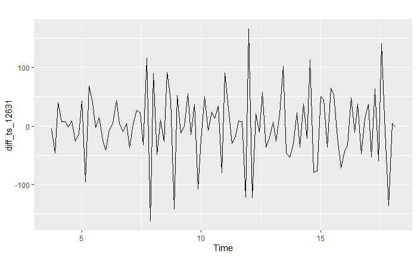

```r
#ts diff
diff_ts_12631 <- diff(ts_12631, differences = 1)
autoplot(diff_ts_12631)
```

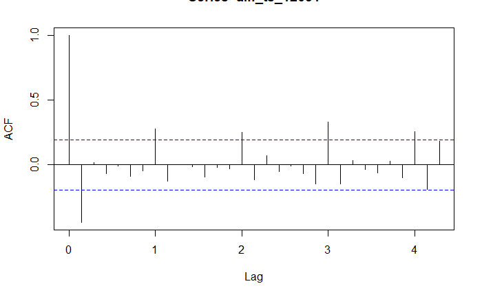

```r
acf(diff_ts_12631, lag.max = 30)
```

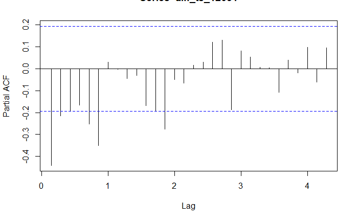

```r
pacf(diff_ts_12631, lag.max = 30)
```

```r
adf.test(diff_ts_12631)
```

```
p-value smaller than printed p-value
```

```
    Augmented Dickey-Fuller Test

data:  diff_ts_12631
Dickey-Fuller = -7.6772, Lag order = 4, p-value = 0.01
alternative hypothesis: stationary
```

```r
kpss.test(diff_ts_12631, null = 'Trend')
```

```
p-value greater than printed p-value
```

```
    KPSS Test for Trend Stationarity

data:  diff_ts_12631
KPSS Trend = 0.023248, Truncation lag parameter = 4, p-value = 0.1
```

```r
pp.test(diff_ts_12631)
```

```
p-value smaller than printed p-value
```

```
    Phillips-Perron Unit Root Test

data:  diff_ts_12631
Dickey-Fuller Z(alpha) = -122.83, Truncation lag parameter = 4, p-value = 0.01
alternative hypothesis: stationary
```

```r
ndiffs(diff_ts_12631)
```

```
[1] 0
```

```r
nsdiffs(diff_ts_12631)
```

```
[1] 0
```

*Figure 2.3:* *This figure provides the ACF and PACF information for store 12631*

As the p-value for Dickey-Fuller and Phillips-Perron Unit Root Test are smaller than 0.01, and the p-value for KPSS Test is larger than 0.01, the result above indicates stationary for the time series dataset. The ndiffs test return the value 0 and the nsdiffs test return the value of 0 after taking one difference, which indicates seasonal stationary.

```r
auto.arima(ts_12631, d=1, trace = TRUE, ic = 'aic', approximation = FALSE)
```

```
 ARIMA(2,1,2)(1,0,1)[7] with drift         : Inf
 ARIMA(0,1,0)           with drift         : 1120.706
 ARIMA(1,1,0)(1,0,0)[7] with drift         : 1090.311
 ARIMA(0,1,1)(0,0,1)[7] with drift         : 1071.138
 ARIMA(0,1,0)                              : 1118.706
 ARIMA(0,1,1)           with drift         : 1073.824
 ARIMA(0,1,1)(1,0,1)[7] with drift         : Inf
 ARIMA(0,1,1)(0,0,2)[7] with drift         : 1065.996
 ARIMA(0,1,1)(1,0,2)[7] with drift         : 1057.133
 ARIMA(0,1,1)(2,0,2)[7] with drift         : Inf
 ARIMA(0,1,1)(2,0,1)[7] with drift         : 1056.861
 ARIMA(0,1,1)(2,0,0)[7] with drift         : 1058.53
 ARIMA(0,1,1)(1,0,0)[7] with drift         : Inf
 ARIMA(0,1,0)(2,0,1)[7] with drift         : Inf
 ARIMA(1,1,1)(2,0,1)[7] with drift         : 1057.934
 ARIMA(0,1,2)(2,0,1)[7] with drift         : 1058.048
 ARIMA(1,1,0)(2,0,1)[7] with drift         : Inf
 ARIMA(1,1,2)(2,0,1)[7] with drift         : Inf
 ARIMA(0,1,1)(2,0,1)[7]                    : Inf

 Best model: ARIMA(0,1,1)(2,0,1)[7] with drift

Series: ts_12631
ARIMA(0,1,1)(2,0,1)[7] with drift

Coefficients:
          ma1    sar1    sar2     sma1   drift
      -0.9218  0.7339  0.1708  -0.6501  0.5394
s.e.   0.0552  0.3613  0.2034   0.4057  0.7841

sigma^2 estimated as 1642:  log likelihood=-522.43
AIC=1056.86   AICc=1057.74   BIC=1072.61
```

#### ARIMA Functions Selected

The best model is determined to be ARIMA(0,1,1)(2,0,1)[7], the second best is ARIMA(0,1,1)(1,0,2)[7]which indicates that we can put ARIMA(0,1,1)(p,0,q) with period 7 into the pool.

```r
arima1_12631 <- Arima(ts_12631, order = c(0, 1 ,1), seasonal = list(order = c(1, 0, 1), period = 7))
arima2_12631 <- Arima(ts_12631, order = c(0, 1 ,1), seasonal = list(order = c(1, 0, 2), period = 7))
arima3_12631 <- Arima(ts_12631, order = c(0, 1 ,1), seasonal = list(order = c(2, 0, 0), period = 7))
arima4_12631 <- Arima(ts_12631, order = c(0, 1 ,1), seasonal = list(order = c(2, 0, 1), period = 7))
arima5_12631 <- Arima(ts_12631, order = c(0, 1 ,1), seasonal = list(order = c(2, 0, 2), period = 7))
```

The forecast function is used on each ARIMA model and used with a 14 period forecast.

```r
# 14 day ARIMA forecast
forecast_arima1_12631 <- forecast(arima1_12631, h = 14)
forecast_arima2_12631 <- forecast(arima2_12631, h = 14)
forecast_arima3_12631 <- forecast(arima3_12631, h = 14)
forecast_arima4_12631 <- forecast(arima4_12631, h = 14)
forecast_arima5_12631 <- forecast(arima5_12631, h = 14)
```

```r
accuracy_arima_12631 <- rbind(forecast::accuracy(forecast_arima1_12631), forecast::accuracy(forecast_arima2_12631), forecast::accuracy(forecast_arima3_12631),
           forecast::accuracy(forecast_arima4_12631), forecast::accuracy(forecast_arima5_12631))

accuracy_arima_12631_k <- data.frame(accuracy_arima_12631,
                                     row.names = c('ARIMA(0,1,1)(1,0,1)',
                                                   'ARIMA(0,1,1)(1,0,2)',
                                                   'ARIMA(0,1,1)(2,0,0)',
                                                   'ARIMA(0,1,1)(2,0,1)',
                                                   'ARIMA(0,1,1)(2,0,2)'))
accuracy_arima_12631_k %>%  kable(caption = "Accuracy of ARIMA Model", align = 'c') %>%  kable_styling(full_width = F)
```

Accuracy of ARIMA Model

|  | ME | RMSE | MAE | MPE | MAPE | MASE | ACF1 |
| --- | --- | --- | --- | --- | --- | --- | --- |
| ARIMA(0,1,1)(1,0,1) | -0.3229760 | 39.09835 | 31.17352 | -2.1295463 | 11.96262 | 0.7933876 | 0.0788720 |
| ARIMA(0,1,1)(1,0,2) | -0.0822262 | 39.28054 | 31.49289 | -2.0339113 | 12.07631 | 0.8015158 | 0.0730922 |
| ARIMA(0,1,1)(2,0,0) | 3.1536713 | 40.53615 | 32.03033 | -0.8807008 | 12.18224 | 0.8151939 | 0.0571999 |
| ARIMA(0,1,1)(2,0,1) | 0.2029572 | 39.31725 | 31.54839 | -1.9192211 | 12.09087 | 0.8029283 | 0.0697389 |
| ARIMA(0,1,1)(2,0,2) | -0.1577580 | 38.71051 | 30.87266 | -2.0270878 | 11.85090 | 0.7857306 | 0.0482676 |

*Table 2.3:* *This table provides the model pool information for store 12631.*

```r
#Training arima
training_arima1_12631 <- arima(train_12631,
                                    order = c(0, 1 ,1),
                                    seasonal = list(order = c(1, 0, 1),
                                                    period = 7))
training_arima5_12631 <- arima(train_12631,
                                    order = c(0, 1 ,1),
                                    seasonal = list(order = c(2, 0, 2),
                                                    period = 7))

## Forecast using the training set
forecast_arima1_12631 <- forecast(training_arima1_12631, h = 19)
forecast_arima5_12631 <- forecast(training_arima5_12631, h = 19)
```

```r
accuracy_final_arima_12631 <- rbind(accuracy(forecast_arima1_12631,
                                            test_12631),
                              accuracy(forecast_arima5_12631,
                                       test_12631))

accuracy_final_arima_12631_k <- data.frame(accuracy_final_arima_12631,
                                          row.names = c('Train_1', 'Test_1',
                                                        'Train_5', 'Test_5'))

accuracy_final_arima_12631_k %>%  kable(caption = "Accuracy of ARIMA Models", align = 'c') %>%  kable_styling(full_width = F) %>%
  pack_rows("ARIMA(0,1,1)(1,0,1)", 1, 2) %>%
  pack_rows("ARIMA(0,1,1)(2,0,2)", 3, 4)
```

Accuracy of ARIMA Models

|  | ME | RMSE | MAE | MPE | MAPE | MASE | ACF1 | Theil.s.U |
| --- | --- | --- | --- | --- | --- | --- | --- | --- |
| **ARIMA(0,1,1)(1,0,1)** |  |  |  |  |  |  |  |  |
| Train_1 | 1.724060 | 38.19502 | 29.54690 | -1.255771 | 11.37481 | 0.8308069 | 0.0067456 | NA |
| Test_1 | -14.637094 | 45.91240 | 41.27985 | -8.064526 | 15.88498 | 1.1607166 | 0.1901771 | 0.7465879 |
| **ARIMA(0,1,1)(2,0,2)** |  |  |  |  |  |  |  |  |
| Train_5 | 1.867089 | 37.95740 | 29.26054 | -1.179982 | 11.27384 | 0.8227549 | 0.0025700 | NA |
| Test_5 | -10.323711 | 44.55224 | 39.72654 | -6.355588 | 15.06637 | 1.1170403 | 0.1452584 | 0.7020115 |

*Table 2.4:* *This table provides the model comparison information for store 12631.*

#### Final ARIMA Model

```r
## Best model plotted
best_arima_12631 <- arima(ts_12631,
                               order = c(0, 1 ,1),
                               seasonal = list(order = c(2, 0, 2),
                                               period = 7))
```

[output not shown]

```r
forecast_best_arima_12631 <- forecast(best_arima_12631, h = 14)
forecast_best_arima_12631_1 <- as.data.frame(forecast_best_arima_12631)

forecast_best_arima_12631_df <- data.frame(forecast_best_arima_12631_1$`Point Forecast`,
                                               row.names = c('16/06/15', '17/06/15', '18/06/15',
                                                             '19/06/15', '20/06/15', '21/06/15',
                                                             '22/06/15', '23/06/15', '24/06/15',
                                                             '25/06/15', '26/06/15', '27/06/15',
                                                             '28/06/15', '29/06/15'))
forecast_best_arima_12631_df %>%  kable(caption = "Final 14 Day ARIMA Forecast", align = 'c',  col.names = 'Lettuce Demand') %>%  kable_styling(full_width = F)
```

Final 14 Day ARIMA Forecast

|  | Lettuce Demand |
| --- | --- |
| 16/06/15 | 262.7753 |
| 17/06/15 | 260.0174 |
| 18/06/15 | 307.4973 |
| 19/06/15 | 284.9511 |
| 20/06/15 | 243.1299 |
| 21/06/15 | 267.8276 |
| 22/06/15 | 255.5832 |
| 23/06/15 | 272.6945 |
| 24/06/15 | 281.7113 |
| 25/06/15 | 321.1607 |
| 26/06/15 | 311.2694 |
| 27/06/15 | 245.7965 |
| 28/06/15 | 262.0703 |
| 29/06/15 | 244.0791 |

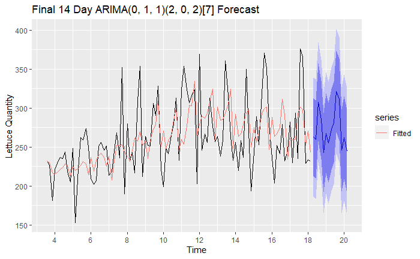

```r
autoplot(forecast_best_arima_12631,
         main = 'Final 14 Day ARIMA(0, 1, 1)(2, 0, 2)[7] Forecast',
         ylab = 'Lettuce Quantity', xlab = 'Time') +
  autolayer(fitted(forecast_best_arima_12631), series = 'Fitted', na.rm=TRUE) +
  scale_x_continuous(breaks = seq(0, 22, by = 2))
```

*Table 2.5:* *This table provides the final prediction value of time series for store 12631.* *Figure 2.4:* *This table provides the final prediction plot for store 12631.*

```
    Ljung-Box test

data:  Residuals from ARIMA(0,1,1)(2,0,2)[7]
Q* = 5.7545, df = 9, p-value = 0.7642

Model df: 5.   Total lags used: 14
```

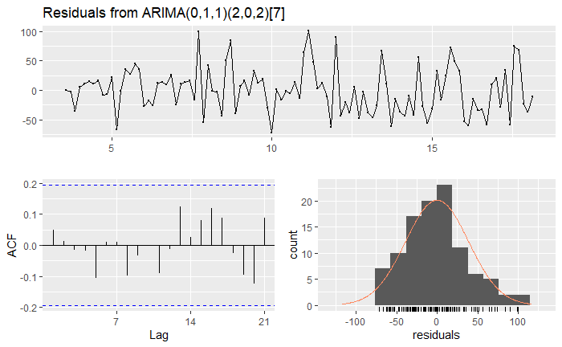

```r
checkresiduals(forecast_best_arima_12631)
```

*Figure 2.5:* *This figure provides the residual and test for store 12631.*

### Final Forecast for Resturant 12631:

The best two selected model will be compared in this section.

```r
## Checking which model based on RMSE
accuracy_final_model_all_12631 <- rbind(forecast::accuracy(forecast_ets_12631, test_12631),
                                       forecast::accuracy(forecast_arima5_12631, test_12631))
accuracy_final_model_all_12631_df <- data.frame(accuracy_final_model_all_12631,
                                               row.names = c('Train_ets', 'Test_ets', 'Train_ts', 'Test_ts'))

accuracy_final_model_all_12631_df %>%  kable(caption = "Accuracy of Best ETS and ARIMA", align = 'c') %>%
  kable_styling(full_width = F) %>%
  pack_rows("ETS", 1, 2) %>%
  pack_rows("ARIMA(0,1,1)(2,0,2)", 3, 4)
```

Accuracy of Best ETS and ARIMA

|  | ME | RMSE | MAE | MPE | MAPE | MASE | ACF1 | Theil.s.U |
| --- | --- | --- | --- | --- | --- | --- | --- | --- |
| **ETS** |  |  |  |  |  |  |  |  |
| Train_ets | -2.160748 | 33.72579 | 25.67783 | -2.501694 | 9.961289 | 0.7220155 | 0.0324235 | NA |
| Test_ets | -21.361420 | 48.24049 | 41.88100 | -10.367304 | 16.591165 | 1.1776202 | -0.1314206 | 0.7898032 |
| **ARIMA(0,1,1)(2,0,2)** |  |  |  |  |  |  |  |  |
| Train_ts | 1.867089 | 37.95740 | 29.26054 | -1.179982 | 11.273842 | 0.8227549 | 0.0025700 | NA |
| Test_ts | -10.323711 | 44.55224 | 39.72654 | -6.355588 | 15.066374 | 1.1170403 | 0.1452584 | 0.7020115 |

*Table 2.6:* *This Table provides the methods comparison information for store 12631.*

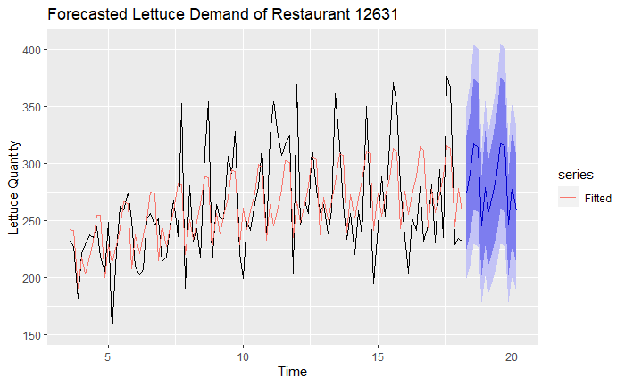

```r
# Best model
final_12631 <- forecast(final_ets_12631, h = 14)

autoplot(final_12631,
         main = 'Forecasted Lettuce Demand of Restaurant 12631',
         ylab = 'Lettuce Quantity',
         xlab = 'Time') +
  autolayer(fitted(final_ets_12631), series = 'Fitted', na.rm=TRUE)
```

```r
#Write to csv
write.csv(final_12631, 'final_12631.csv')

## Final Forecast (Table)
final_12631_1 <- as.data.frame(forecast(final_ets_12631, h = 14))
final_store_12631_df <- data.frame(final_12631_1$`Point Forecast`,
                                 row.names = c('16/06/15', '17/06/15', '18/06/15', '19/06/15',
                                               '20/06/15', '21/06/15', '22/06/15', '23/06/15',
                                               '24/06/15', '25/06/15', '26/06/15', '27/06/15',
                                               '28/06/15', '29/06/15'))
final_store_12631_df %>%  kable(caption = "Final 14 Day ETS Forecast", align = 'c', col.names = 'Lettuce Demand') %>%  kable_styling(full_width = F)
```

Final 14 Day ETS Forecast

|  | Lettuce Demand |
| --- | --- |
| 16/06/15 | 274.2683 |
| 17/06/15 | 289.9449 |
| 18/06/15 | 316.5410 |
| 19/06/15 | 313.7897 |
| 20/06/15 | 245.1401 |
| 21/06/15 | 278.4584 |
| 22/06/15 | 257.8716 |
| 23/06/15 | 275.0112 |
| 24/06/15 | 290.7099 |
| 25/06/15 | 317.3545 |
| 26/06/15 | 314.5752 |
| 27/06/15 | 245.7378 |
| 28/06/15 | 279.1198 |
| 29/06/15 | 258.4683 |

*Figure 2.6:* *This figure provides the final forecasting plot for store 12631.*  
*Table 2.7:* *This table provides the final forecasting value for store 12631.*